# Introduction to the smapr package

Maxwell B. Joseph

2019-04-21

```r
library(smapr)
library(sp)
library(raster)
```

This vignette outlines a basic use scenario for smapr. We will acquire and process [NASA (Soil Moisture Active-Passive) SMAP data](http://smap.jpl.nasa.gov/), and generate some simple visualizations.

## SMAP data products

Multiple SMAP data products are provided by the NSIDC, and these products vary in the amount of processing. Currently, smapr primarily supports level 3 and level 4 data products, which represent global daily composite and global three hourly modeled data products, respectively. NSIDC provides documentation for all SMAP data products on their [website](https://nsidc.org/data/smap/smap-data.html), and we provide a summary of data products supported by smapr below.

| Dataset id | Description | Resolution |
| --- | --- | --- |
| SPL2SMAP_S | SMAP/Sentinel-1 Radiometer/Radar Soil Moisture | 3 km |
| SPL3FTA | Radar Northern Hemisphere Daily Freeze/Thaw State | 3 km |
| SPL3SMA | Radar Global Daily Soil Moisture | 3 km |
| SPL3SMP | Radiometer Global Soil Moisture | 36 km |
| SPL3SMAP | Radar/Radiometer Global Soil Moisture | 9 km |
| SPL4SMAU | Surface/Rootzone Soil Moisture Analysis Update | 9 km |
| SPL4SMGP | Surface/Rootzone Soil Moisture Geophysical Data | 9 km |
| SPL4SMLM | Surface/Rootzone Soil Moisture Land Model Constants | 9 km |
| SPL4CMDL | Carbon Net Ecosystem Exchange | 9 km |

This vignette uses the level 4 SPL4SMAU (Surface/Rootzone Soil Moisture Analysis Update) data product.

## Preparing to access SMAP data

NASA requires a username and password from their Earthdata portal to access SMAP data. You can get these credentials here: https://earthdata.nasa.gov/

Once you have your credentials, you can use the `set_smap_credentials` function to set them for use by the smapr package:

```r
set_smap_credentials("myusername", "mypassword")
```

This function saves your credentials for later use unless you use the argument `save = FALSE`.

## Finding data

```r
available_data <- find_smap(id = 'SPL4SMAU', dates = '2018-06-01', version = 4)
```

This returns a data frame, where every row is one data file that is available on NASA’s servers.

```r
str(available_data)
```

```
#> 'data.frame':    8 obs. of  3 variables:
#>  $ name: chr  "SMAP_L4_SM_aup_20180601T030000_Vv4030_001" "SMAP_L4_SM_aup_20180601T060000_Vv4030_001" "SMAP_L4_SM_aup_20180601T090000_Vv4030_001" "SMAP_L4_SM_aup_20180601T120000_Vv4030_001" ...
#>  $ date: Date, format: "2018-06-01" "2018-06-01" ...
#>  $ dir : chr  "SPL4SMAU.004/2018.06.01/" "SPL4SMAU.004/2018.06.01/" "SPL4SMAU.004/2018.06.01/" "SPL4SMAU.004/2018.06.01/" ...
```

## Downloading data

To download the data, we can use `download_smap`. Note that this may take a while, depending on the number of files being downloaded, and the speed of your internet connection. Because we’re downloading multiple files, we will use the `verbose = FALSE` argument to avoid printing excessive output to the console.

```r
local_files <- download_smap(available_data, overwrite = FALSE, verbose = FALSE)
```

Each file corresponds to different times as indicated by the file names:

```r
local_files$name[1:2]
```

```
#> [1] "SMAP_L4_SM_aup_20180601T030000_Vv4030_001"
#> [2] "SMAP_L4_SM_aup_20180601T060000_Vv4030_001"
```

## Exploring data

Each file that we downloaded is an HDF5 file with multiple datasets bundled together. To list all of the data in a file we can use `list_smap`. By default, if we give `list_smap` a data frame of local files, it will return a list of data frames. Because all of these data files are of the same data product, using `list_smap` on one file (e.g., the first) will tell us what’s available in all of the files:

```r
list_smap(local_files[1, ])
```

```
#> $SMAP_L4_SM_aup_20180601T030000_Vv4030_001
#>    group                    name       otype  dclass         dim
#> 0      /           Analysis_Data   H5I_GROUP
#> 1      / EASE2_global_projection H5I_DATASET  STRING           1
#> 2      /           Forecast_Data   H5I_GROUP
#> 3      /                Metadata   H5I_GROUP
#> 4      /       Observations_Data   H5I_GROUP
#> 5      /             cell_column H5I_DATASET INTEGER 3856 x 1624
#> 6      /                cell_lat H5I_DATASET   FLOAT 3856 x 1624
#> 7      /                cell_lon H5I_DATASET   FLOAT 3856 x 1624
#> 8      /                cell_row H5I_DATASET INTEGER 3856 x 1624
#> 9      /                    time H5I_DATASET   FLOAT           1
#> 10     /                       x H5I_DATASET   FLOAT        3856
#> 11     /                       y H5I_DATASET   FLOAT        1624
```

To dig deeper, we can use the `all` argument to `list_smap`:

```r
list_smap(local_files[1, ], all = TRUE)
```

```
#> $SMAP_L4_SM_aup_20180601T030000_Vv4030_001
#>                                  group                             name
#> 0                                    /                    Analysis_Data
#> 1                       /Analysis_Data              sm_profile_analysis
#> 2                       /Analysis_Data       sm_profile_analysis_ensstd
#> 3                       /Analysis_Data             sm_rootzone_analysis
#> 4                       /Analysis_Data      sm_rootzone_analysis_ensstd
#> 5                       /Analysis_Data              sm_surface_analysis
#> 6                       /Analysis_Data       sm_surface_analysis_ensstd
#> 7                       /Analysis_Data        soil_temp_layer1_analysis
#> 8                       /Analysis_Data soil_temp_layer1_analysis_ensstd
#> 9                       /Analysis_Data            surface_temp_analysis
#> 10                      /Analysis_Data     surface_temp_analysis_ensstd
#> 11                                   /          EASE2_global_projection
#> 12                                   /                    Forecast_Data
```

[output cut: 128 more lines]

Looking at this output, we can conclude that the file contains multiple arrays (notice the `dim` column). These arrays correspond to things like estimated root zone soil moisture (`/Analysis_Data/sm_rootzone_analysis`), estimated surface soil moisture (`/Analysis_Data/sm_surface_analysis`), and estimated surface temperature (`/Analysis_Data/surface_temp_analysis`). See https://nsidc.org/data/smap/spl4sm/data-fields#sm_surface_analysis for more detailed information on what these datasets represent and how they were generated.

## Extracting data

The datasets that we are interested in are spatial grids. The `smapr` package can extract these data into `raster` objects with the `extract_smap` function, which takes a dataset name as an argument. These names are paths that can be generated from the output of `list_smap`. For example, if we want to get rootzone soil moisture, we can see a dataset with name `sm_rootzone_analysis` in group `/Analysis_Data`, so that the path to the dataset is `/Analysis_Data/sm_rootzone_analysis`:

```r
sm_raster <- extract_smap(local_files, '/Analysis_Data/sm_rootzone_analysis')







```

This will extract all of the data in the data frame `local_files`, generating a RasterBrick with one layer per file:

```r
sm_raster
```

```
#> class       : RasterBrick
#> dimensions  : 1624, 3856, 6262144, 8  (nrow, ncol, ncell, nlayers)
#> resolution  : 9008.055, 9008.055  (x, y)
#> extent      : -17367530, 17367530, -7314541, 7314541  (xmin, xmax, ymin, ymax)
#> coord. ref. : +proj=cea +lon_0=0 +lat_ts=30 +x_0=0 +y_0=0 +datum=WGS84 +units=m +no_defs +ellps=WGS84 +towgs84=0,0,0
#> data source : /home/max/.cache/smap/tmp.tif
#> names       : SMAP_L4_S//Vv4030_001, SMAP_L4_S//Vv4030_001, SMAP_L4_S//Vv4030_001, SMAP_L4_S//Vv4030_001, SMAP_L4_S//Vv4030_001, SMAP_L4_S//Vv4030_001, SMAP_L4_S//Vv4030_001, SMAP_L4_S//Vv4030_001
#> min values  :            0.01099210,            0.01104227,            0.01111004,            0.01108601,            0.01082948,            0.01094369,            0.01094055,            0.01095674
#> max values  :             0.7999770,             0.7999318,             0.8000000,             0.7999870,             0.8000000,             0.8000000,             0.7999970,             0.7999533
```

We can visualize each layer in our RasterBrick:

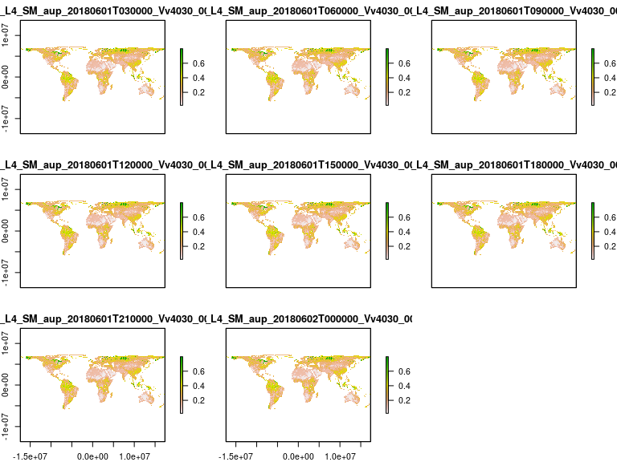

```r
plot(sm_raster)
```

## Common downstream operations

### Study region cropping and masking

If you want to crop the data to a study region, you can use the `raster::crop` function. Let’s illustrate by focusing on the state of Colorado, which is approximately rectangular, so that we can define an `extent` object using latitude and longitude values that roughly correspond to the state boundaries. The `raster::extent()` function can be used with any `Spatial*` or `Raster*` object.

```r
co_extent <- extent(c(-109, -102, 37, 41))
co_extent <- as(co_extent, "SpatialPolygons")
sp::proj4string(co_extent) <- "+proj=longlat +ellps=WGS84 +datum=WGS84 +no_defs"
co_extent
```

```
#> class       : SpatialPolygons
#> features    : 1
#> extent      : -109, -102, 37, 41  (xmin, xmax, ymin, ymax)
#> coord. ref. : +proj=longlat +ellps=WGS84 +datum=WGS84 +no_defs +towgs84=0,0,0
```

Now that we have a SpatialPolygons object, we can use this to crop the soil moisture raster to our study region. First, we need to ensure that the projections are the same:

```r
proj_co_extent <- spTransform(co_extent, crs(sm_raster))
```

Then, we could crop the soil moisture data to our polygon, which will make the extents match.

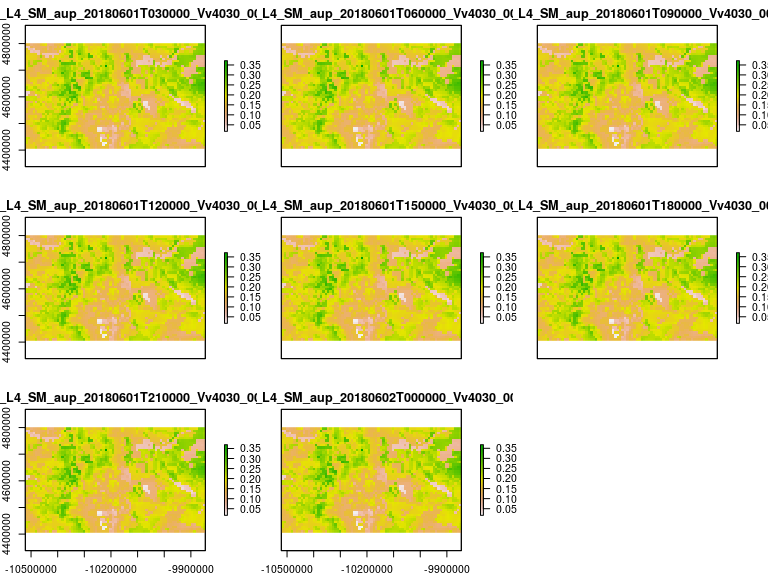

```r
co_soil_moisture <- crop(sm_raster, proj_co_extent)
plot(co_soil_moisture)
```

We might also have a polygon to use as a mask. For example, to mask out our Colorado polygon, we could do the following (operating on the first layer of the soil moisture raster for simplicity):

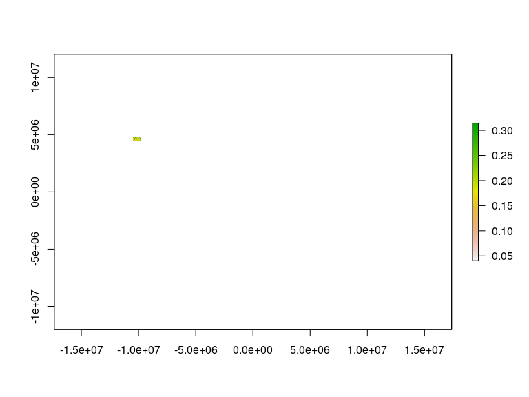

```r
plot(mask(sm_raster[[1]], proj_co_extent))
```

Notice that masking does not crop the raster, it simply sets all values outside of the polygon to NA. In some cases, an inverse mask is useful, where values inside the polygon are set to NA:

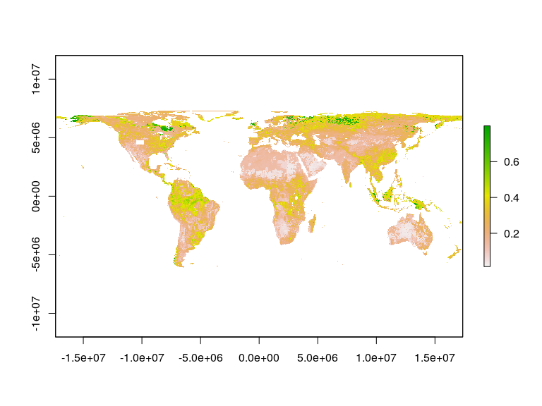

```r
plot(mask(sm_raster[[1]], proj_co_extent, inverse = TRUE))
```

### Computing summary statistics over layers

We may want to average soil moisture values across layers of a raster brick. This can be done with the `raster::calc()` function:

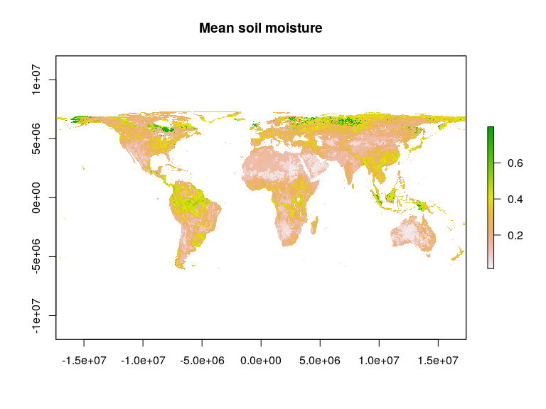

```r
mean_sm <- calc(sm_raster, fun = mean)
plot(mean_sm, main = 'Mean soil moisture')
```

### Comparing surface and soil moisture

Our SPL4SMAU data have estimated surface and rootzone soil moisture layers. If we want to compare these values, we can load the surface soil moisture data, compute the mean value over layers as we did for the rootzone soil moisture raster, and generate a scatterplot.

```r
surface_raster <- extract_smap(local_files,
                               name = '/Analysis_Data/sm_surface_analysis')







```

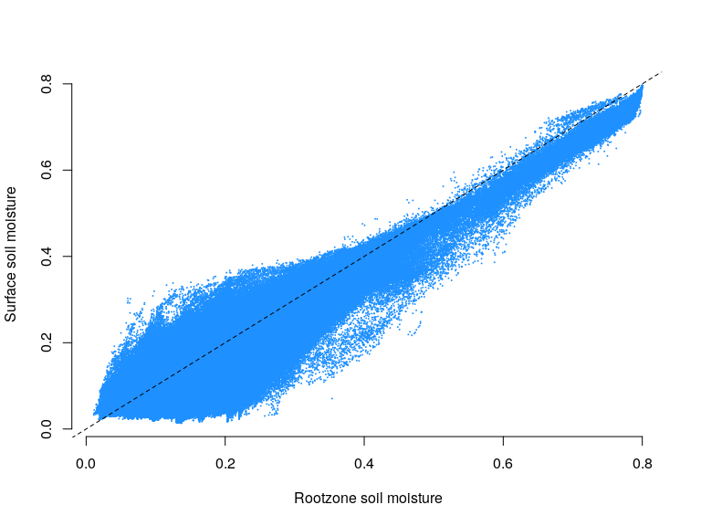

```r
# compute mean
mean_surface_sm <- calc(surface_raster, fun = mean)

# compare values
plot(values(mean_sm), values(mean_surface_sm), col = 'dodgerblue', cex = .1,
     xlab = 'Rootzone soil moisture', ylab = 'Surface soil moisture', bty = 'n')
abline(0, 1, lty = 2)
```